# Development Priorities in Rwanda compared to Nigeria - World Bank Country Survey 2013

## Disclaimer

This study is done as my personal study project. Any possible errors are highly regretted, I am still learning statistics.

## Motivation

This study aims at comparing opinions on issues citizens are facing in Rwanda and Nigeria - two African countries belonging to two different regions (Great Lakes and West Africa respectively). Both countries are classified as low income countries by the World Bank. In Nigeria, GDP per capita is 1,091.6 USD, in Rwanda, more than two times less 417.7 USD (Source: [World Bank](http://data.worldbank.org/indicator/NY.GDP.PCAP.KD)). It might be interesting to see if opinions of citiezens of these two countries differ. Of course, no causal link with the GDP can be established since this is an observational study. We are not going to establish any form correlation either. This is just a descriptive analysis.

## Research question

### Compare the opinions of citizen of Rwanda and Nigeria on General Development Priorities (Section A2)

Respondents could choose up to 3 priorities.

## Source

[World Bank Country Survey 2013](http://microdata.worldbank.org/index.php/catalog/1923/download/29784) [Documentation](http://microdata.worldbank.org/index.php/ddibrowser/1923/export/?format=pdf&generate=yes)

## Load data from the World Bank Country survey 2013

```r
#temp <- tempfile()
#download.file("http://microdata.worldbank.org/index.php/catalog/1923/download/29784",temp, mode="wb")
#unzip(temp, "COS FY2013 Annual Review Data.csv")
raw_world <- read.csv("COS FY2013 Annual Review Data.csv")
#unlink(temp)
#Kenya code 107
#South Africa code 110
rwanda <- subset(raw_world, country==236)
nigeria <- subset(raw_world, country==230)
```

## Exploratory data analysis

### Rwanda

Number of participants in the survey:

```r
gen_rwanda = rwanda[,7:45]
nrow(gen_rwanda)
```

```
## [1] 732
```

Not Available (NA) values (missing values):

```r
summary(gen_rwanda)
```

```
##       a2_1              a2_2              a2_3              a2_4
##  Min.   :0.00000   Min.   :0.00000   Min.   :0.00000   Min.   :0.00000
##  1st Qu.:0.00000   1st Qu.:0.00000   1st Qu.:0.00000   1st Qu.:0.00000
##  Median :0.00000   Median :0.00000   Median :0.00000   Median :0.00000
##  Mean   :0.07692   Mean   :0.06044   Mean   :0.07006   Mean   :0.06593
##  3rd Qu.:0.00000   3rd Qu.:0.00000   3rd Qu.:0.00000   3rd Qu.:0.00000
##  Max.   :1.00000   Max.   :1.00000   Max.   :1.00000   Max.   :1.00000
##  NA's   :4         NA's   :4         NA's   :4         NA's   :4
##       a2_5             a2_6             a2_7              a2_8
##  Min.   :0.0000   Min.   :0.0000   Min.   :0.00000   Min.   :0.00000
##  1st Qu.:0.0000   1st Qu.:0.0000   1st Qu.:0.00000   1st Qu.:0.00000
##  Median :0.0000   Median :0.0000   Median :0.00000   Median :0.00000
##  Mean   :0.1277   Mean   :0.1442   Mean   :0.05769   Mean   :0.06319
##  3rd Qu.:0.0000   3rd Qu.:0.0000   3rd Qu.:0.00000   3rd Qu.:0.00000
##  Max.   :1.0000   Max.   :1.0000   Max.   :1.00000   Max.   :1.00000
##  NA's   :4        NA's   :4        NA's   :4         NA's   :4
##       a2_9            a2_10            a2_11             a2_12
##  Min.   :0.0000   Min.   :0.0000   Min.   :0.00000   Min.   :0.00000
##  1st Qu.:0.0000   1st Qu.:0.0000   1st Qu.:0.00000   1st Qu.:0.00000
##  Median :0.0000   Median :0.0000   Median :0.00000   Median :0.00000
##  Mean   :0.1154   Mean   :0.2184   Mean   :0.08929   Mean   :0.05769
##  3rd Qu.:0.0000   3rd Qu.:0.0000   3rd Qu.:0.00000   3rd Qu.:0.00000
##  Max.   :1.0000   Max.   :1.0000   Max.   :1.00000   Max.   :1.00000
##  NA's   :4        NA's   :4        NA's   :4         NA's   :4
##      a2_13             a2_14             a2_15             a2_16
##  Min.   :0.00000   Min.   :0.00000   Min.   :0.00000   Min.   :0.0000
##  1st Qu.:0.00000   1st Qu.:0.00000   1st Qu.:0.00000   1st Qu.:0.0000
##  Median :0.00000   Median :0.00000   Median :0.00000   Median :0.0000
##  Mean   :0.02473   Mean   :0.01374   Mean   :0.01648   Mean   :0.3997
##  3rd Qu.:0.00000   3rd Qu.:0.00000   3rd Qu.:0.00000   3rd Qu.:1.0000
##  Max.   :1.00000   Max.   :1.00000   Max.   :1.00000   Max.   :1.0000
##  NA's   :4         NA's   :4         NA's   :4         NA's   :4
##      a2_17            a2_18            a2_19             a2_20
##  Min.   :0.0000   Min.   :0.0000   Min.   :0.00000   Min.   :0.0000
##  1st Qu.:0.0000   1st Qu.:0.0000   1st Qu.:0.00000   1st Qu.:0.0000
##  Median :0.0000   Median :0.0000   Median :0.00000   Median :0.0000
##  Mean   :0.3736   Mean   :0.2761   Mean   :0.09478   Mean   :0.0783
##  3rd Qu.:1.0000   3rd Qu.:1.0000   3rd Qu.:0.00000   3rd Qu.:0.0000
##  Max.   :1.0000   Max.   :1.0000   Max.   :1.00000   Max.   :1.0000
##  NA's   :4        NA's   :4        NA's   :4         NA's   :4
```

[output cut: 25 more lines]

```
##  Min.   : NA   Min.   : NA   Min.   : NA   Min.   : NA   Min.   :0.0000
##  1st Qu.: NA   1st Qu.: NA   1st Qu.: NA   1st Qu.: NA   1st Qu.:0.0000
##  Median : NA   Median : NA   Median : NA   Median : NA   Median :0.0000
##  Mean   :NaN   Mean   :NaN   Mean   :NaN   Mean   :NaN   Mean   :0.1717
##  3rd Qu.: NA   3rd Qu.: NA   3rd Qu.: NA   3rd Qu.: NA   3rd Qu.:0.0000
##  Max.   : NA   Max.   : NA   Max.   : NA   Max.   : NA   Max.   :1.0000
##  NA's   :732   NA's   :732   NA's   :732   NA's   :732   NA's   :4
##      a2_40         a2_41
##  Min.   : NA   Min.   :0.00000
##  1st Qu.: NA   1st Qu.:0.00000
##  Median : NA   Median :0.00000
##  Mean   :NaN   Mean   :0.03434
##  3rd Qu.: NA   3rd Qu.:0.00000
##  Max.   : NA   Max.   :1.00000
##  NA's   :732   NA's   :4
```

We see that most of the variables (question options) have 4 missing values (NAs). However, eight variables have all 732 values missing. It is possible that the corresponding options were not available in Rwanda. We will drop these columns (a2_27,a2_31, a2_33 - a2_36, a2_40, please see the documentation for the exact titles). These columns contain no information, so there is no loss of information.

```r
gen_rwanda.sub <- subset(gen_rwanda, select=-c(a2_24, a2_27, a2_31, a2_33, a2_34, a2_35, a2_36, a2_40))
```

Now let us see if the four NAs in other columns correspond to the same rows, i.e. if there are rows containing only NA values (empty rows).

```r
nrow(gen_rwanda.sub)-nrow(gen_rwanda.sub[complete.cases(gen_rwanda.sub),])
```

```
## [1] 4
```

We can see that there are 4 empty rows which we will drop (the loss of data will be about 0.5% only).

```r
gen_rwanda.sub = gen_rwanda.sub[complete.cases(gen_rwanda.sub),]
```

### Top 10 answers in Rwanda

```r
gen_rwanda.top10 <- sort(colSums(gen_rwanda.sub), decreasing = T)[1:10]; gen_rwanda.top10
```

```
## a2_16 a2_17 a2_18 a2_25 a2_10 a2_38  a2_6  a2_5  a2_9 a2_19
##   291   272   201   163   159   125   105    93    84    69
```

Let us consult the exact option titles from the dictionary

1. a2_16 Health
2. a2_17 Education
3. a2_18 Povery reduction
4. a2_25 Economic growth
5. a2_10 Job creation/employment
6. a2_38 Agriculture and rural development
7. a2_6 Domestic private sector development
8. a2_5 Gender
9. a2_9 Anti-corruption
10. a2_19 Energy

### Percentage of respondents per priority

```r
rwanda_top10.names <- c("Health", "Education", "Poverty reduction", "Economic growth",
                        "Job creation/employment","Agriculture and rural development",
                        "Domestic private sector development", "Gender", "Anti-corruption", "Energy")
names(gen_rwanda.top10) = rwanda_top10.names
round((gen_rwanda.top10/nrow(gen_rwanda.sub)*100),2)
```

```
##                              Health                           Education
##                               39.97                               37.36
##                   Poverty reduction                     Economic growth
##                               27.61                               22.39
##             Job creation/employment   Agriculture and rural development
##                               21.84                               17.17
## Domestic private sector development                              Gender
##                               14.42                               12.77
##                     Anti-corruption                              Energy
##                               11.54                                9.48
```

*Note: The percentage values do not sum to 100% since the respondents could choose up to 3 priorities*

```r
rwanda.top10.df <- data.frame(prior = rwanda_top10.names, val=gen_rwanda.top10)
```

## Plot Rwanda’s Top 10 Development Priorities

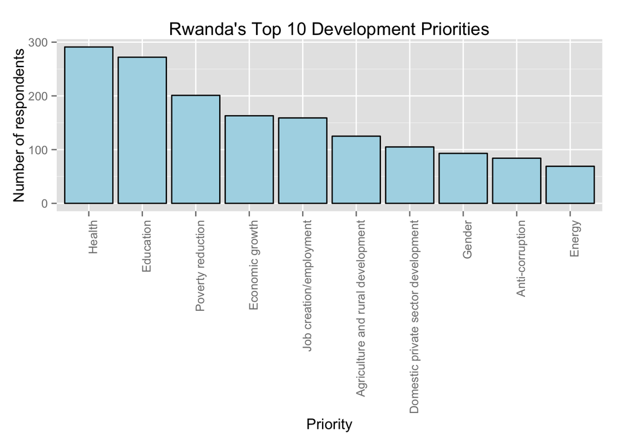

```r
library(ggplot2)
# make prior an ordered factor to avoid ggplot ordering alphabetically x-axis labels in barplot
rwanda.top10.df$prior <- factor(rwanda.top10.df$prior, levels = rwanda.top10.df$prior)
ggplot(rwanda.top10.df, aes(x=prior, y=val)) +
geom_bar(stat="identity", colour="black", fill="lightblue") +
theme(axis.text.x = element_text(angle = 90, hjust = 1)) +
xlab("Priority") +
ylab("Number of respondents") +
ggtitle("Rwanda's Top 10 Development Priorities")
```

## Nigeria

Number of participants in the survey:

```r
gen_nigeria = nigeria[,7:45]
nrow(gen_nigeria)
```

```
## [1] 835
```

Not Available (NA) values (missing values):

```r
summary(gen_nigeria)
```

```
##       a2_1              a2_2              a2_3             a2_4
##  Min.   :0.00000   Min.   :0.00000   Min.   :0.0000   Min.   :0.00000
##  1st Qu.:0.00000   1st Qu.:0.00000   1st Qu.:0.0000   1st Qu.:0.00000
##  Median :0.00000   Median :0.00000   Median :0.0000   Median :0.00000
##  Mean   :0.04902   Mean   :0.04167   Mean   :0.1618   Mean   :0.03064
##  3rd Qu.:0.00000   3rd Qu.:0.00000   3rd Qu.:0.0000   3rd Qu.:0.00000
##  Max.   :1.00000   Max.   :1.00000   Max.   :1.0000   Max.   :1.00000
##  NA's   :19        NA's   :19        NA's   :19       NA's   :19
##       a2_5              a2_6              a2_7              a2_8
##  Min.   :0.00000   Min.   :0.00000   Min.   :0.00000   Min.   :0.00000
##  1st Qu.:0.00000   1st Qu.:0.00000   1st Qu.:0.00000   1st Qu.:0.00000
##  Median :0.00000   Median :0.00000   Median :0.00000   Median :0.00000
##  Mean   :0.01471   Mean   :0.02696   Mean   :0.02206   Mean   :0.03922
##  3rd Qu.:0.00000   3rd Qu.:0.00000   3rd Qu.:0.00000   3rd Qu.:0.00000
##  Max.   :1.00000   Max.   :1.00000   Max.   :1.00000   Max.   :1.00000
##  NA's   :19        NA's   :19        NA's   :19        NA's   :19
##       a2_9            a2_10            a2_11            a2_12
##  Min.   :0.0000   Min.   :0.0000   Min.   :0.0000   Min.   :0.000000
##  1st Qu.:0.0000   1st Qu.:0.0000   1st Qu.:0.0000   1st Qu.:0.000000
##  Median :0.0000   Median :0.0000   Median :0.0000   Median :0.000000
##  Mean   :0.2586   Mean   :0.3015   Mean   :0.2341   Mean   :0.009804
##  3rd Qu.:1.0000   3rd Qu.:1.0000   3rd Qu.:0.0000   3rd Qu.:0.000000
##  Max.   :1.0000   Max.   :1.0000   Max.   :1.0000   Max.   :1.000000
##  NA's   :19       NA's   :19       NA's   :19       NA's   :19
##      a2_13             a2_14             a2_15             a2_16
##  Min.   :0.00000   Min.   :0.00000   Min.   :0.00000   Min.   :0.0000
##  1st Qu.:0.00000   1st Qu.:0.00000   1st Qu.:0.00000   1st Qu.:0.0000
##  Median :0.00000   Median :0.00000   Median :0.00000   Median :0.0000
##  Mean   :0.01716   Mean   :0.01593   Mean   :0.02574   Mean   :0.1299
##  3rd Qu.:0.00000   3rd Qu.:0.00000   3rd Qu.:0.00000   3rd Qu.:0.0000
##  Max.   :1.00000   Max.   :1.00000   Max.   :1.00000   Max.   :1.0000
##  NA's   :19        NA's   :19        NA's   :19        NA's   :19
##      a2_17            a2_18            a2_19            a2_20
##  Min.   :0.0000   Min.   :0.0000   Min.   :0.0000   Min.   :0.00000
##  1st Qu.:0.0000   1st Qu.:0.0000   1st Qu.:0.0000   1st Qu.:0.00000
##  Median :0.0000   Median :0.0000   Median :0.0000   Median :0.00000
##  Mean   :0.4522   Mean   :0.2194   Mean   :0.1973   Mean   :0.05637
##  3rd Qu.:1.0000   3rd Qu.:0.0000   3rd Qu.:0.0000   3rd Qu.:0.00000
##  Max.   :1.0000   Max.   :1.0000   Max.   :1.0000   Max.   :1.00000
##  NA's   :19       NA's   :19       NA's   :19       NA's   :19
```

[output cut: 25 more lines]

```
##  Min.   : NA   Min.   : NA   Min.   : NA   Min.   : NA   Min.   :0.0000
##  1st Qu.: NA   1st Qu.: NA   1st Qu.: NA   1st Qu.: NA   1st Qu.:0.0000
##  Median : NA   Median : NA   Median : NA   Median : NA   Median :0.0000
##  Mean   :NaN   Mean   :NaN   Mean   :NaN   Mean   :NaN   Mean   :0.3505
##  3rd Qu.: NA   3rd Qu.: NA   3rd Qu.: NA   3rd Qu.: NA   3rd Qu.:1.0000
##  Max.   : NA   Max.   : NA   Max.   : NA   Max.   : NA   Max.   :1.0000
##  NA's   :835   NA's   :835   NA's   :835   NA's   :835   NA's   :19
##      a2_40         a2_41
##  Min.   : NA   Min.   :0.0000
##  1st Qu.: NA   1st Qu.:0.0000
##  Median : NA   Median :0.0000
##  Mean   :NaN   Mean   :0.0527
##  3rd Qu.: NA   3rd Qu.:0.0000
##  Max.   : NA   Max.   :1.0000
##  NA's   :835   NA's   :19
```

We see that most of the variables (question options) have 19 missing values (NAs). However, five variables have all 835 values missing. It is possible that the corresponding options were not available in Nigeria. We will drop these columns (a2_33, a2_34, a2_35,a2_36, a2_40, please see the documentation for the exact titles). These columns contain no information, so there is no loss of information.

```r
gen_nigeria.sub <- subset(gen_nigeria, select=-c(a2_33, a2_34, a2_35, a2_36, a2_40))
```

Now let us see if the 19 NAs in other columns correspond to the same rows, i.e. if there are rows containing only NA values (empty rows).

```r
nrow(gen_nigeria.sub)-nrow(gen_nigeria.sub[complete.cases(gen_nigeria.sub),])
```

```
## [1] 19
```

We can see that there are 19 empty rows which we will drop (the loss of data will be slightly more than 2%).

```r
gen_nigeria.sub = gen_nigeria.sub[complete.cases(gen_nigeria.sub),]
```

### Top 10 answers in Nigeria

```r
gen_nigeria.top10 <- sort(colSums(gen_nigeria.sub), decreasing = T)[1:10]; gen_nigeria.top10
```

```
## a2_17 a2_38 a2_10  a2_9 a2_11 a2_18 a2_29 a2_19  a2_3 a2_22
##   369   286   246   211   191   179   172   161   132   118
```

Let us consult the exact option titles from the dictionary

1. a2_17 Education
2. a2_38 Agriculture and rural development
3. a2_10 Job creation/employment
4. a2_9 Anti-corruption
5. a2_11 Rural development
6. a2_18 Povery reduction
7. a2_29 Basic infrastructure
8. a2_19 Energy
9. a2_3 Public sector governance/reform
10. a2_22 Agricultural development

### Percentage of respondents per priority

```r
nigeria_top10.names <- c("Education", "Agriculture and rural development", "Job creation/employment",
                         "Anti-corruption", "Rural development", "Povery reduction", "Basic infrastructure",
                         "Energy", "Public sector governance/reform", "Agricultural development")
names(gen_nigeria.top10) = nigeria_top10.names
round((gen_nigeria.top10/nrow(gen_nigeria.sub)*100),2)
```

```
##                         Education Agriculture and rural development
##                             45.22                             35.05
##           Job creation/employment                   Anti-corruption
##                             30.15                             25.86
##                 Rural development                  Povery reduction
##                             23.41                             21.94
##              Basic infrastructure                            Energy
##                             21.08                             19.73
##   Public sector governance/reform          Agricultural development
##                             16.18                             14.46
```

*Note: The percentage values do not sum to 100% since the respondents could choose up to 3 priorities*

```r
nigeria.top10.df <- data.frame(prior = nigeria_top10.names, val=gen_nigeria.top10)
```

## Plot Nigeria’s Top 10 Development Priorities

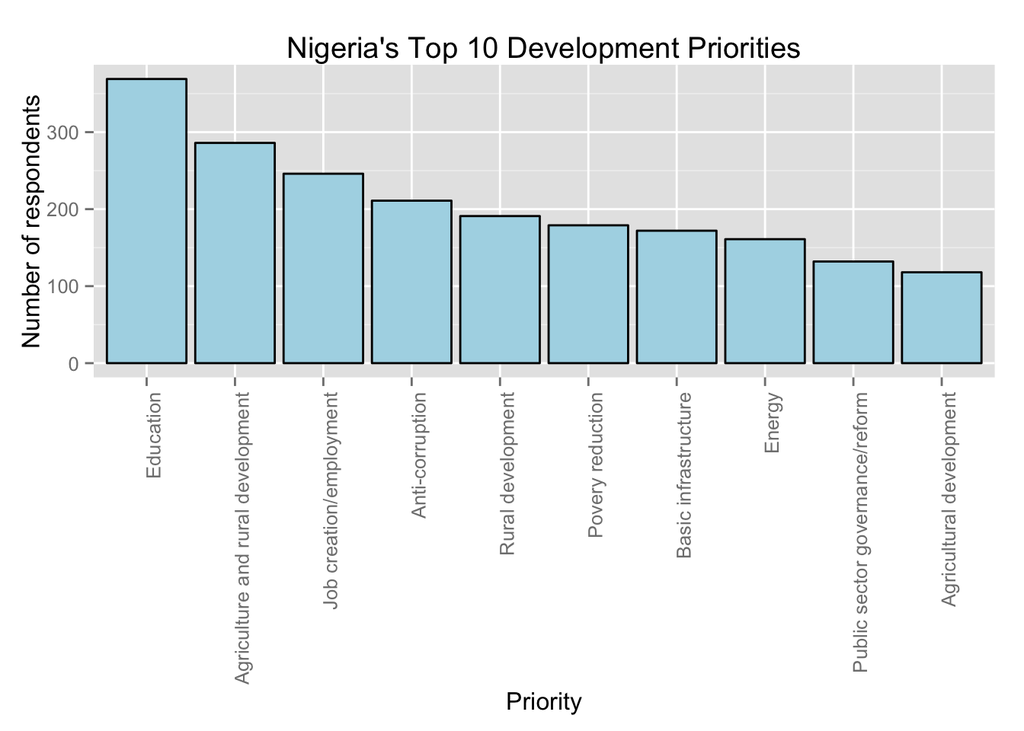

```r
#library(ggplot2)
# make prior an ordered factor to avoid ggplot ordering alphabetically x-axis labels in barplot
nigeria.top10.df$prior <- factor(nigeria.top10.df$prior, levels = nigeria.top10.df$prior)
ggplot(nigeria.top10.df, aes(x=prior, y=val)) +
geom_bar(stat="identity", colour="black", fill="lightblue") +
theme(axis.text.x = element_text(angle = 90, hjust = 1)) +
xlab("Priority") +
ylab("Number of respondents") +
ggtitle("Nigeria's Top 10 Development Priorities")
```

## Rwanda Top 10 Development Priorities compared to the corresponding priorities in Nigeria (percentage)

```r
comp <- subset(gen_nigeria.sub, select= c(a2_16, a2_17, a2_18, a2_25, a2_10, a2_38, a2_6, a2_5, a2_9, a2_19))

nigeria.comp.rwandatop10 <- sort(colSums(comp), decreasing = T); nigeria.comp.rwandatop10
```

```
## a2_17 a2_38 a2_10  a2_9 a2_18 a2_19 a2_16 a2_25  a2_6  a2_5
##   369   286   246   211   179   161   106    53    22    12
```

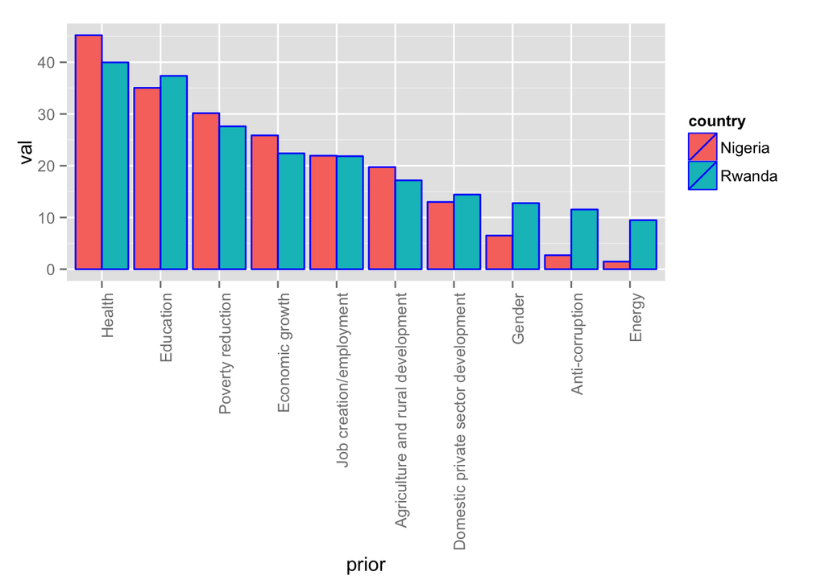

```r
nigeria.comp.rwandatop10.df <- data.frame(prior = rwanda_top10.names,
                         val=round((nigeria.comp.rwandatop10/nrow(comp)*100),2))
nigeria.comp.rwandatop10.df$country <- rep("Nigeria", 10)
rwandatop10.comp.df <- rwanda.top10.df
rwandatop10.comp.df$val <- round(((rwandatop10.comp.df$val/nrow(gen_rwanda.sub))*100),2)
rwandatop10.comp.df$country <- rep("Rwanda", 10)
nr <- rbind(nigeria.comp.rwandatop10.df, rwandatop10.comp.df)

# make prior an ordered factor to avoid ggplot ordering alphabetically x-axis labels in barplot
nr$prior <- factor(nr$prior, levels = nr$prior)
plt <- ggplot(nr, aes(x=prior, y=val, fill=country)) +
geom_bar(stat="identity", colour="blue", position = "dodge") +
theme(axis.text.x = element_text(angle = 90, hjust = 1))
suppressWarnings(print(plt))
```